# Project Business Statistics: E-news Express

## Define Problem Statement and Objectives

### Business Context

The advent of e-news, or electronic news, portals has offered us a great opportunity to quickly get updates on the day-to-day events occurring globally. The information on these portals is retrieved electronically from online databases, processed using a variety of software, and then transmitted to the users. There are multiple advantages of transmitting new electronically, like faster access to the content and the ability to utilize different technologies such as audio, graphics, video, and other interactive elements that are either not being used or aren’t common yet in traditional newspapers.

E-news Express, an online news portal, aims to expand its business by acquiring new subscribers. With every visitor to the website taking certain actions based on their interest, the company plans to analyze these actions to understand user interests and determine how to drive better engagement. The executives at E-news Express are of the opinion that there has been a decline in new monthly subscribers compared to the past year because the current webpage is not designed well enough in terms of the outline & recommended content to keep customers engaged long enough to make a decision to subscribe.

### A/B Testing

I will analyze user responses to two variants of a product to decide which of the two variants is more effective. This experimental technique, known as A/B testing, is used to determine whether a new feature attracts users based on a chosen metric.

### Objective, Data Background, and Questions to Address

The design team of the company has researched and created a new landing page that has a new outline & more relevant content shown compared to the old page. In order to test the effectiveness of the new landing page in gathering new subscribers, the Data Science team conducted an experiment by randomly selecting 100 users and dividing them equally into two groups. The existing landing page was served to the first group (control group) and the new landing page to the second group (treatment group). Data regarding the interaction of users in both groups with the two versions of the landing page was collected.

I will explore the data and perform a statistical analysis (at a significance level of 5%) to determine the effectiveness of the new landing page in gathering new subscribers for the news portal by answering the following questions:

> -Do the users spend more time on the new landing page than on the existing landing page?

> -Is the conversion rate (the proportion of users who visit the landing page and get converted) for the new page greater than the conversion rate for the old page?

> -Does the converted status depend on the preferred language?

> -Is the time spent on the new page the same for the different language users?

### Data Dictionary

The data contains information regarding the interaction of users in both groups with the two versions of the landing page.

> user_id - Unique user ID of the person visiting the website

> group - Whether the user belongs to the first group (control) or the second group (treatment)

> landing_page - Whether the landing page is new or old

> time_spent_on_the_page - Time (in minutes) spent by the user on the landing page

> converted - Whether the user gets converted to a subscriber of the news portal or not

> language_preferred - Language chosen by the user to view the landing page

## Import all the necessary libraries

```python
# Libraries to help with reading and manipulating data
import pandas as pd
import numpy as np
from statsmodels.stats.proportion import proportions_ztest

# Libraries to help with data visualization
import matplotlib.pyplot as plt
import seaborn as sns
%matplotlib inline

# Library to help with statistical analysis
import scipy.stats as stats

# Function for handling normal distribution and statistical calculation
from scipy.stats import norm
```

**Note**: *After running the above cell, kindly restart the notebook kernel and run all cells sequentially from the start again.*

## Reading the Data into a DataFrame

```python
# Mount my google drive
from google.colab import drive
drive.mount('/content/drive')
```

```python
# Loading the dataset
path = "/content/drive/MyDrive/abtest.csv"
data = pd.read_csv(path)
```

```python
# Copying data to another variable to avoid any changes to original data
df = data.copy()
```

## Explore the dataset and extract insights using Exploratory Data Analysis

- Data Overview
  - Viewing the first and last few rows of the dataset
  - Checking the shape of the dataset
  - Getting the statistical summary for the variables
- Check for missing values
- Check for duplicates

##### Data Overview

```python
# Viewing the first and last few rows of the dataset
pd.concat([df.head(), df.tail()])
```

|  | user_id | group | landing_page | time_spent_on_the_page | converted | language_preferred |
| --- | --- | --- | --- | --- | --- | --- |
| 0 | 546592 | control | old | 3.48 | no | Spanish |
| 1 | 546468 | treatment | new | 7.13 | yes | English |
| 2 | 546462 | treatment | new | 4.40 | no | Spanish |
| 3 | 546567 | control | old | 3.02 | no | French |
| 4 | 546459 | treatment | new | 4.75 | yes | Spanish |
| 95 | 546446 | treatment | new | 5.15 | no | Spanish |
| 96 | 546544 | control | old | 6.52 | yes | English |
| 97 | 546472 | treatment | new | 7.07 | yes | Spanish |
| 98 | 546481 | treatment | new | 6.20 | yes | Spanish |
| 99 | 546483 | treatment | new | 5.86 | yes | English |

```python
# Checking the shape of the dataset
df.shape
```

```
(100, 6)
```

```python
# Getting the statistical summary for the variables
df.describe().T
```

|  | count | mean | std | min | 25% | 50% | 75% | max |
| --- | --- | --- | --- | --- | --- | --- | --- | --- |
| user_id | 100.0 | 546517.0000 | 52.295779 | 546443.00 | 546467.75 | 546492.500 | 546567.2500 | 546592.00 |
| time_spent_on_the_page | 100.0 | 5.3778 | 2.378166 | 0.19 | 3.88 | 5.415 | 7.0225 | 10.71 |

```python
# Summary of all variables in df
df.describe(include='all').T
```

|  | count | unique | top | freq | mean | std | min | 25% | 50% | 75% | max |
| --- | --- | --- | --- | --- | --- | --- | --- | --- | --- | --- | --- |
| user_id | 100.0 | NaN | NaN | NaN | 546517.0 | 52.295779 | 546443.0 | 546467.75 | 546492.5 | 546567.25 | 546592.0 |
| group | 100 | 2 | control | 50 | NaN | NaN | NaN | NaN | NaN | NaN | NaN |
| landing_page | 100 | 2 | old | 50 | NaN | NaN | NaN | NaN | NaN | NaN | NaN |
| time_spent_on_the_page | 100.0 | NaN | NaN | NaN | 5.3778 | 2.378166 | 0.19 | 3.88 | 5.415 | 7.0225 | 10.71 |
| converted | 100 | 2 | yes | 54 | NaN | NaN | NaN | NaN | NaN | NaN | NaN |
| language_preferred | 100 | 3 | Spanish | 34 | NaN | NaN | NaN | NaN | NaN | NaN | NaN |

```python
# Info of df variables
df.info()
```

```
<class 'pandas.core.frame.DataFrame'>
RangeIndex: 100 entries, 0 to 99
Data columns (total 6 columns):
 #   Column                  Non-Null Count  Dtype
---  ------                  --------------  -----
 0   user_id                 100 non-null    int64
 1   group                   100 non-null    object
 2   landing_page            100 non-null    object
 3   time_spent_on_the_page  100 non-null    float64
 4   converted               100 non-null    object
 5   language_preferred      100 non-null    object
dtypes: float64(1), int64(1), object(4)
memory usage: 4.8+ KB
```

##### Check for Missing Values

```python
# Checking for missing values in df
df.isnull().sum()
```

```
user_id                   0
group                     0
landing_page              0
time_spent_on_the_page    0
converted                 0
language_preferred        0
dtype: int64
```

Observation: There are no missing values in the df.

##### Checking for Duplicate Values

```python
# Check for duplicate values in df
df.duplicated().sum()
```

```
0
```

Observation: There are no duplicates in the df.

```python
# Check for unique count of each variable in df
df.nunique()
```

```
user_id                   100
group                       2
landing_page                2
time_spent_on_the_page     94
converted                   2
language_preferred          3
dtype: int64
```

### Univariate Analysis

##### Group Counts

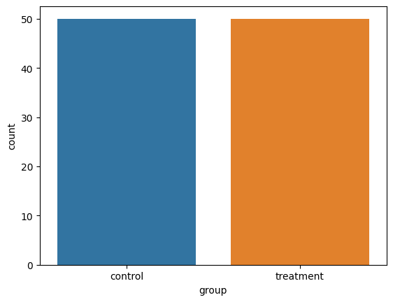

```python
# Graph of group counts
sns.countplot(data=df, x='group', hue='group', legend=False)
```

```python
# Count of group
df['group'].value_counts()
```

```
group
control      50
treatment    50
Name: count, dtype: int64
```

Observation: The control and treatment group have equal as expected.

##### Landing Page Counts

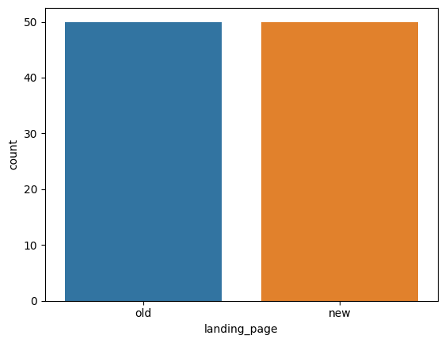

```python
#Graph of landing page counts
sns.countplot(data=df, x='landing_page', hue='landing_page', legend=False)
```

```python
# Count of landing page
df['landing_page'].value_counts()
```

```
landing_page
old    50
new    50
Name: count, dtype: int64
```

Observation: The control and treatment group have equal participants as expected.

##### Time Spent on Page Distribution

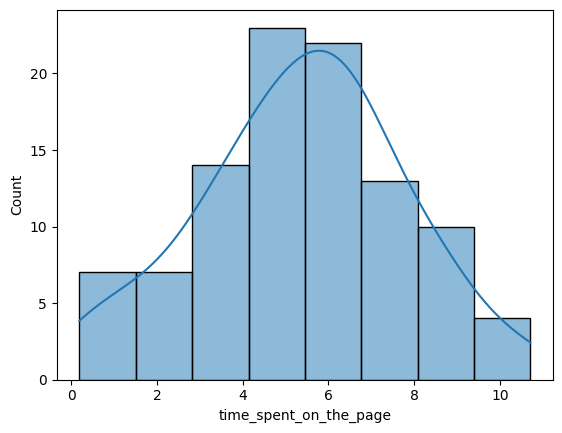

```python
# Plotting histogram of time spent on page for all groups
sns.histplot(data=df, x='time_spent_on_the_page', kde=True)
```

Most users spend between 3 to 8 minutes on the pages.

##### Count of Converted vs Not-Converted

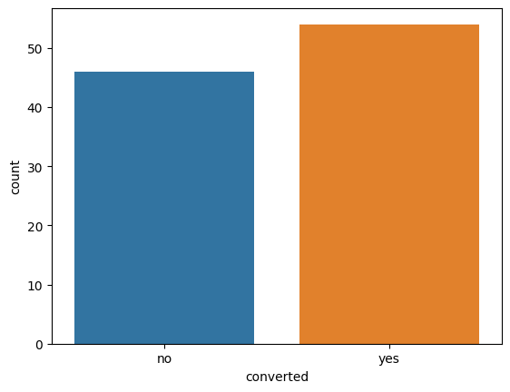

```python
# Plotting histogram of coverted
sns.countplot(data=df, x='converted', hue='converted', legend=False)
```

```python
# Count of converted
df['converted'].value_counts()
```

```
converted
yes    54
no     46
Name: count, dtype: int64
```

Observe that there are more converted than not converted.

```python
# Show converted for new_df and old_df
df.groupby('landing_page')['converted'].value_counts()
```

```
landing_page  converted
new           yes          33
              no           17
old           no           29
              yes          21
Name: count, dtype: int64
```

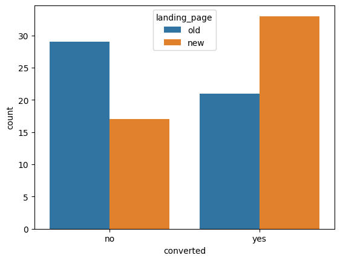

```python
# Visualize new_df conversion and old_df conversion
sns.countplot(data=df, x='converted', hue='landing_page', legend=True)
```

We can see a trend that the new page is showing a higher conversion rate!

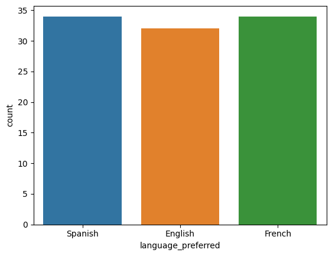

```python
# Plotting a histogram of language preferred
sns.countplot(data=df, x='language_preferred', hue='language_preferred', legend=False)
```

```python
# Language preferred count
df['language_preferred'].value_counts()
```

```
language_preferred
Spanish    34
French     34
English    32
Name: count, dtype: int64
```

There are three languages represented in the sample data.

Observe that languages preferred is almost equally distributed across the sample data, with English having slightly less than French and Spanish.

### Bivariate Analysis

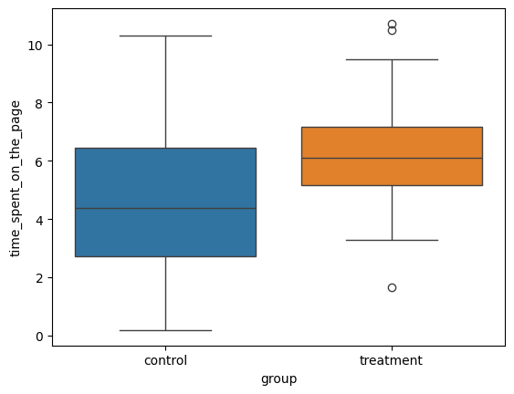

```python
# Display time spent on each page by group type
sns.boxplot(data=df, x='group', y='time_spent_on_the_page', hue='group')
```

The treatment group is showing higher time spent with less variance than the control group.

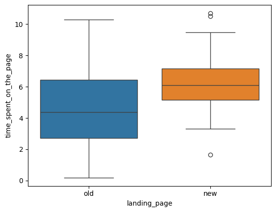

```python
# Display time spent on each page by landing page
sns.boxplot(data=df, x='landing_page', y='time_spent_on_the_page', hue='landing_page')
```

This graph reinforces that the new page was given to the treatment group, and the old page is our control group.

```python
# Language preferred by group
pd.crosstab(df['language_preferred'], df['group'])
```

| group language_preferred | control | treatment |
| --- | --- | --- |
| English | 16 | 16 |
| French | 17 | 17 |
| Spanish | 17 | 17 |

Each language preference group was equally split into the control and treatment groups.

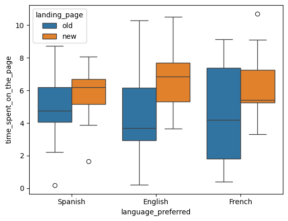

```python
# Graph of time spent on page by language group new vs old
sns.boxplot(data=df, x='language_preferred', y='time_spent_on_the_page', hue='landing_page')
```

```python
# Average time spent on page by language group old vs new
df.groupby(['language_preferred', 'landing_page'])['time_spent_on_the_page'].mean()
```

```
language_preferred  landing_page
English             new             6.663750
                    old             4.454375
French              new             6.196471
                    old             4.310000
Spanish             new             5.835294
                    old             4.828235
Name: time_spent_on_the_page, dtype: float64
```

The median and mean time spent increased for all language groups using the new landing page.

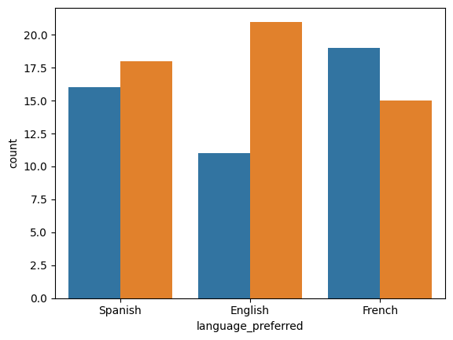

```python
# Graph of converted by language preferred
sns.countplot(data=df, x='language_preferred', hue='converted', legend=False)
```

English and Spanish showed higher conversion compared to the French language users.

```python
# Converted by Language Preferred
pd.crosstab(df['language_preferred'], df['converted'])
```

| converted language_preferred | no | yes |
| --- | --- | --- |
| English | 11 | 21 |
| French | 19 | 15 |
| Spanish | 16 | 18 |

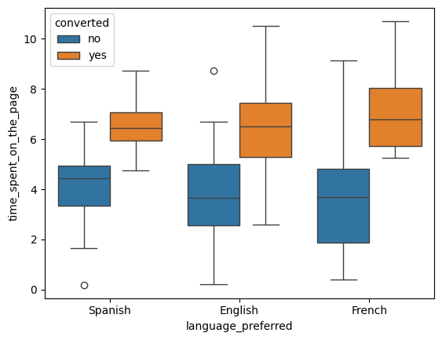

```python
# Display time spent on page with converted by language
sns.boxplot(data=df, x='language_preferred', y='time_spent_on_the_page', hue='converted')
```

The average time spent of those that converted is higher for all language groups. We see a trend happenning above the 5 minute mark. Over 75% of those that converted engaged for over 5 minutes.

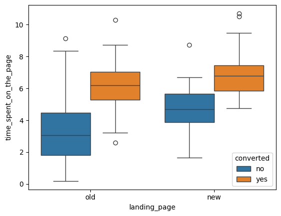

```python
# Display time spent on page with converted by language new vs old
sns.boxplot(data=df, x='landing_page', y='time_spent_on_the_page', hue='converted')
```

A common thread of those converted is time spent, for the old page and the new page.

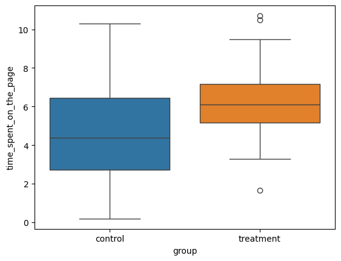

```python
# Display boxplots by group with hue
sns.boxplot(data=df, x='group', y='time_spent_on_the_page', hue='group')
```

The treatment group shows more time spent on the page.

```python
# Compare stats of time spent on page by group
df.groupby('group')['time_spent_on_the_page'].describe()
```

| group | count | mean | std | min | 25% | 50% | 75% | max |
| --- | --- | --- | --- | --- | --- | --- | --- | --- |
| control | 50.0 | 4.5324 | 2.581975 | 0.19 | 2.720 | 4.380 | 6.4425 | 10.30 |
| treatment | 50.0 | 6.2232 | 1.817031 | 1.65 | 5.175 | 6.105 | 7.1600 | 10.71 |

Based off of the visual analysis and the table, the treatment group (new page group) is showing a higher avg time of engagement. We see an indication that more time leads to conversion.

## 1. Do the users spend more time on the new landing page than the existing landing page?

### Perform Visual Analysis

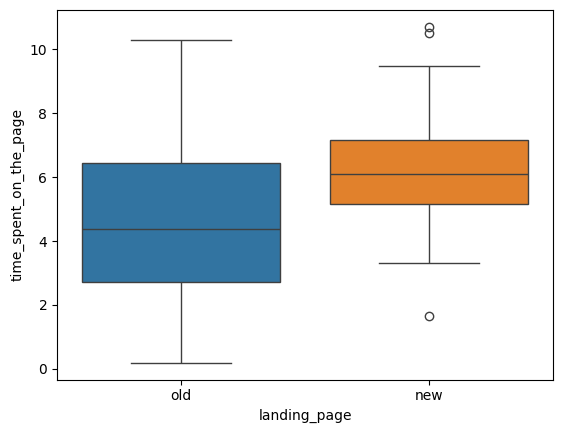

```python
# Visual Analysis of time spent on new vs old landing page
sns.boxplot(data=df, x='landing_page', y='time_spent_on_the_page', hue='landing_page')
```

### Step 1: Define the null and alternate hypotheses

The null and alternative hypotheses can be formulated as:

> $H_0$ : The mean time spent on the new landing page is less than or equal to the mean time spent on the old landing page.  
> $H_a$ : The mean time spent on the new landing page is greater than the old landing page.

### Step 3: Decide the significance level

We will use a significance level of 0.05

### Step 4: Collect and prepare data

```python
#Divide the df based on landing page
new_df = df[df['landing_page'] == 'new']
old_df = df[df['landing_page'] == 'old']
```

```python
# Show the old df statistical summary
old_df.describe().T
```

|  | count | mean | std | min | 25% | 50% | 75% | max |
| --- | --- | --- | --- | --- | --- | --- | --- | --- |
| user_id | 50.0 | 546566.5000 | 17.677670 | 546493.00 | 546555.25 | 546567.50 | 546579.7500 | 546592.0 |
| time_spent_on_the_page | 50.0 | 4.5324 | 2.581975 | 0.19 | 2.72 | 4.38 | 6.4425 | 10.3 |

The average time spent on the existing page is 4.5 minutes

```python
# Show new df statistical summary
new_df.describe().T
```

|  | count | mean | std | min | 25% | 50% | 75% | max |
| --- | --- | --- | --- | --- | --- | --- | --- | --- |
| user_id | 50.0 | 546467.5000 | 14.577380 | 546443.00 | 546455.250 | 546467.500 | 546479.75 | 546492.00 |
| time_spent_on_the_page | 50.0 | 6.2232 | 1.817031 | 1.65 | 5.175 | 6.105 | 7.16 | 10.71 |

The average time spent on the new page is 6.22 minutes Over 75% of the sample spent more than 5 minutes on the page.

### Step 5: Calculate the p-value

```python
#Calculate the p value
t_statistic, p_value = stats.ttest_ind(new_df['time_spent_on_the_page'], old_df['time_spent_on_the_page'], alternative='greater')
print('P Value:', p_value)
```

```
P Value: 0.0001316123528095005
```

### Step 6: Compare the p-value with $\alpha$

```python
# print the conclusion based on p-value
if p_value < 0.05:
    print(f'As the p-value {p_value} is less than the level of significance, we reject the null hypothesis.')
else:
    print(f'As the p-value {p_value} is greater than the level of significance, we fail to reject the null hypothesis.')
```

```
As the p-value 0.0001316123528095005 is less than the level of significance, we reject the null hypothesis.
```

### Step 7: Draw inference

At 5% significance level, we reject the null hypothesis. We have enough statistical evidence to say that the mean time spent on the new landing page is greater than the mean time spent on the old landing page.

**A similar approach can be followed to answer the other questions.**

## 2. Is the conversion rate (the proportion of users who visit the landing page and get converted) for the new page greater than the conversion rate for the old page?

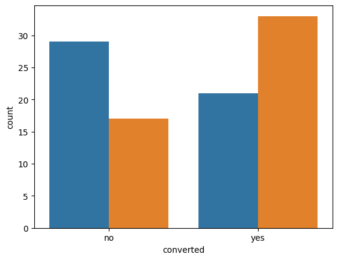

```python
# Color chart of old df conversion and new df conversion
sns.countplot(data=df, x='converted', hue='landing_page', legend=False)
```

The null and alternative hypotheses can be formulated as:

> $H_0$ : The conversion rate proportion of the new page is equal or less than the conversion rate proportion of the old page.  
> $H_a$ : The conversion rate proportion of the new page is greater than the conversion rate proportion of the old page.

We will use a significance level of 0.05

We can calculate the conversion rate data for each sample (old and new)

```python
# Find the count of converted in the old df
old_df['converted'].value_counts()
```

```
converted
no     29
yes    21
Name: count, dtype: int64
```

```python
conversion_rate_old = 21/50
conversion_rate_old
```

```
0.42
```

```python
# Find the count of converted in the new df
new_df['converted'].value_counts()
```

```
converted
yes    33
no     17
Name: count, dtype: int64
```

```python
conversion_rate_new = 33/50
conversion_rate_new
```

```
0.66
```

We will address these rates in our conclusion and recommendation.

Performing the test with the data:

```python
# Perform a one tailed two proportion z-test for conversion_rate_old and
# conversion_rate_new
count = np.array([21, 33])
nobs = np.array([50, 50])
stat, pval = proportions_ztest(count, nobs)
print('P Value:', pval)
```

```
P Value: 0.016052616408112556
```

Our p value is less than the level of significance (0.05), so we will reject the null hypothesis.

```python
# Printing our conclusion
print('At 5% significance level,')
if pval < 0.05:
  print('We reject the null hypothesis.')
  print('Yes, the conversion rate for the new page is significantly greater than the conversion rate for the old page.')
else:
  print('No, the conversion rate for the new page is not greater than the conversion rate for the old page.')
```

```
At 5% significance level,
We reject the null hypothesis.
Yes, the conversion rate for the new page is significantly greater than the conversion rate for the old page.
```

## 3. Is the conversion and preferred language are independent or related?

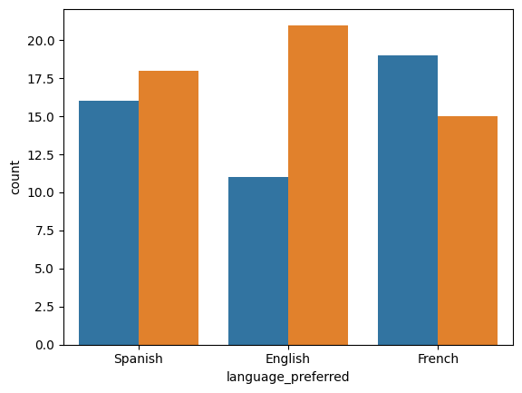

```python
# Visual of conversion and preferred language
sns.countplot(data=df, x='language_preferred', hue='converted', legend=False)
```

> $H_0$ : Conversion rate proportion and preferred language are independent.  
> $H_a$ : Conversion rate and preferred language are associated.

We will perform a chi-square test of independence to assess the equality of proportions across the three language groups since we have bivariate, discrete data.

We will use a significance level of 0.05

Data:

```python
# Test independence for conversion and preferred language
pd.crosstab(df['converted'], df['language_preferred'])
```

| language_preferred converted | English | French | Spanish |
| --- | --- | --- | --- |
| no | 11 | 19 | 16 |
| yes | 21 | 15 | 18 |

```python
converted_eng = 21/32
converted_fre = 15/34
converted_spa = 18/34

print('Conversion Rate for English:', converted_eng)
print('Conversion Rate for French:', converted_fre)
print('Conversion Rate for Spanish:', converted_spa)
```

```
Conversion Rate for English: 0.65625
Conversion Rate for French: 0.4411764705882353
Conversion Rate for Spanish: 0.5294117647058824
```

```python
# Chi square test for independence
chi2, p, dof, expected = stats.chi2_contingency(pd.crosstab(df['converted'], df['language_preferred']))
print('P Value:', p)
```

```
P Value: 0.21298887487543447
```

Our p value is greater than our alpha (0.05) so we fail to reject the null hypothesis. Although the conversion rate differs for each group, there is not enough statistical evidence to show association with preferred language and conversion rate.

## 4. Is the time spent on the new page same for the different language users?

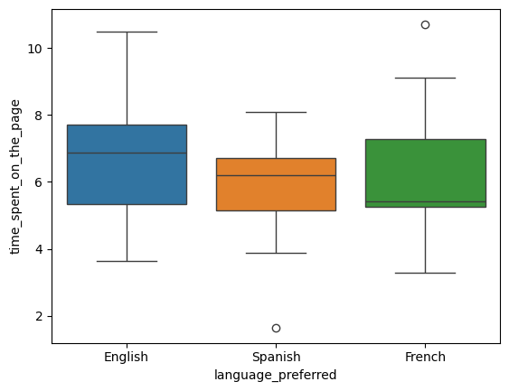

```python
# visual new_df time spent and language
sns.boxplot(data=new_df, x='language_preferred', y='time_spent_on_the_page', hue='language_preferred')
```

> $H_0$ : Average time spent on the new page is the same for different preferred languages.  
> $H_a$ : At least one of the averages for time spent on the new page is not the same across different preferred languages .

Since we have bivariate data, with discrete and continuous variables, we can use a one-way ANOVA F-Test

We will use a 0.05 level of significance

Gathering Data:

```python
# For new_df show stats for language preferred and time spent
new_df.groupby('language_preferred')['time_spent_on_the_page'].describe()
```

| language_preferred | count | mean | std | min | 25% | 50% | 75% | max |
| --- | --- | --- | --- | --- | --- | --- | --- | --- |
| English | 16.0 | 6.663750 | 1.984150 | 3.65 | 5.3275 | 6.865 | 7.7125 | 10.50 |
| French | 17.0 | 6.196471 | 1.933394 | 3.30 | 5.2500 | 5.420 | 7.2700 | 10.71 |
| Spanish | 17.0 | 5.835294 | 1.525656 | 1.65 | 5.1500 | 6.200 | 6.7000 | 8.08 |

```python
# arrays of time spent by language preferred in new_df
eng_newtime = new_df[new_df['language_preferred'] == 'English']['time_spent_on_the_page']
fre_newtime = new_df[new_df['language_preferred'] == 'French']['time_spent_on_the_page']
spa_newtime = new_df[new_df['language_preferred'] == 'Spanish']['time_spent_on_the_page']
```

```python
# One-way anova test
stats.f_oneway(eng_newtime, fre_newtime, spa_newtime)
```

```
F_onewayResult(statistic=0.8543992770006822, pvalue=0.43204138694325955)
```

The p value is 0.43 which is greater than our alpha value of 0.05, so we fail to reject the null hypothesis.

We do not have enough statistical evidence to say that time spent on the new page is different among the preferred language groups.

## Conclusion and Business Recommendations

1. At a 5% significance level, we can say that users spend more time on the new landing page than the existing landing page.
2. Also, at 5% significance we can conclude the conversion rate for the new page is greater than the conversion rate for the old page.
3. We do not have enough statistical evidence to say that conversion rate and preferred language are associated.
4. We do not have enough statistical evidence to say that time spent on the new page is different among the preferred language groups.

*Recommendation: Through statistical and bivariate analysis, we have evidence to strongly recommend using the new page over the existing page. We have also shown with 95% confidence that this improves conversion rate and will drive business forward.

Also, it is worth noting that for this random sample the conversion rate with the new page was 0.66 versus a 0.42 conversion rate with the existing page sample. For this dataset, this shows a 57% increase in subscibers for those using the new page.

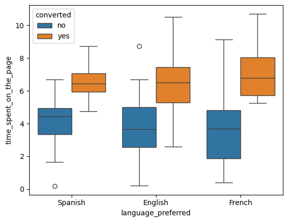

```python
# Showing the conversion picture for more than 5 minutes on the page.
sns.boxplot(data=df, x='language_preferred', y='time_spent_on_the_page', hue='converted')
```

As shown earlier, the new page averaged over 6 minutes of engagement, while the existing page averaged 4.5 minutes. This, along with an increased conversion supports the recommendation for using the new page to drive growth.

```python
%%shell
jupyter nbconvert --to html /content/ENews_Express_Learner_Notebook_Full_CodeDRproject2.ipynb
```

```
[NbConvertApp] Converting notebook /content/ENews_Express_Learner_Notebook_Full_CodeDRproject2.ipynb to html
[NbConvertApp] Writing 1112198 bytes to /content/ENews_Express_Learner_Notebook_Full_CodeDRproject2.html
```